# Bioestatística - Avaliação 1

João Lucas Simon

Cartão UFRGS: 00324507

18/02/2023

# Introdução

Os dados utilizados contém informações sobre variáveis potencialmente associadas à presença de doença cardiovascular (DCV) em homens adultos residentes em uma determinada comunidade. O quadro abaixo descreve as variáveis disponíveis, contendo informações aferidas na linha de base do estudo, isto é, sem considerar o seguimento dos indivíduos ao longo do tempo.

VARIÁVEL

DESCRIÇÃO

age

Idade (anos)

totchol

Colesterol total (mmol/l)

bmi

Índice de massa corporal ($kg/m^2$)

systol

Pressão arterial sistólica (mmHg)

smoking

Categorias do tabagismo:

- 1 = Nunca fumou
- 2 = Ex-tabagista
- 3 = Tabagista

activity

Autorrelato do nível de atividade física:

- 1 = Ativo
- 2 = Atividade média
- 3 = Inativo

chd

Incidência de doença cardiovascular (DCV)

- 0 = Não
- 1 = Sim

Visualização do banco de dados

| id | age | totchol | bmi | systol | smoking | activity | chd |
| --- | --- | --- | --- | --- | --- | --- | --- |
| 1 | 46 | 8.660333 | 30.83653 | 128 | 1 | 1 | 0 |
| 2 | 42 | 6.243496 | 21.67126 | 129 | 3 | 2 | 0 |
| 3 | 45 | 7.748424 | 26.54321 | 121 | 3 | 2 | 0 |
| 4 | 41 | 7.300000 | 19.03811 | 123 | 3 | 2 | 0 |
| 5 | 52 | 6.629518 | 24.96801 | 132 | 1 | 2 | 0 |
| 6 | 48 | 4.833674 | 22.64738 | 147 | 3 | 1 | 0 |

# Análise Descritiva

A seguir, iremos realizar uma análise descritiva para uma melhor compreensão dos dados que estamos lidando. Iremos primeiro analisar as variáveis numéricas utilizando gráficos de box-plot, e as variáveis categóricas utilizando graficos de barra.

### Variáveis numéricas

As variáveis numericas presentes são: ‘age’, ‘totchol’, ‘bmi’ e ‘systol’.

```r
##### SEPARANDO AS VARIÁVEIS NUMÉRICAS
var_num <- dados_tabagismo %>% select('age', 'totchol', 'bmi', 'systol')


#### DESCRITIVA
aux <- stat.desc(var_num)

aux <- aux[c(4, 5, 8, 9, 12:14), ]
rownames(aux) <- c("Mínimo", "Máximo", "Mediana", "Média", "Variância", "Desvio Padrão", "Coeficiente de Variação")
kable(aux, digits = 3, align = "c", caption = "Principais Estatísticas descritivas do banco de dados")
```

Principais Estatísticas descritivas do banco de dados

|  | age | totchol | bmi | systol |
| --- | --- | --- | --- | --- |
| Mínimo | 40.000 | 2.848 | 15.549 | 82.000 |
| Máximo | 59.000 | 12.445 | 42.593 | 221.000 |
| Mediana | 49.000 | 6.294 | 25.826 | 131.000 |
| Média | 49.111 | 6.372 | 26.025 | 132.924 |
| Variância | 32.232 | 1.335 | 11.113 | 323.151 |
| Desvio Padrão | 5.677 | 1.155 | 3.334 | 17.976 |
| Coeficiente de Variação | 0.116 | 0.181 | 0.128 | 0.135 |

Abaixo, conseguimos visualizar o gráfico box-plot de cada variável em sua própria escala.

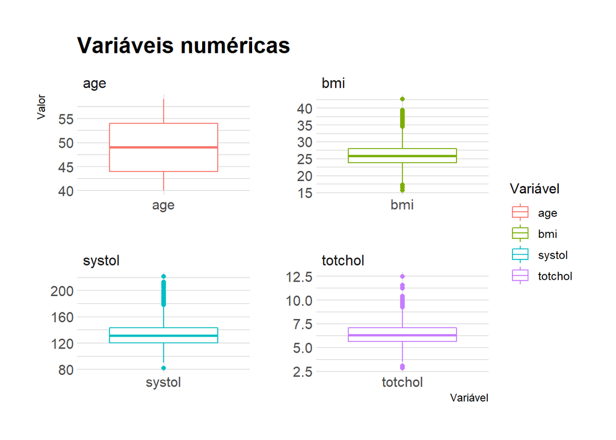

```r
# creating a plot
aux2 <- gather(var_num)
colnames(aux2) <- c("Variável", "Valor")


ggplot(aux2) +
  geom_boxplot(aes(x = Variável, y = Valor, colour = Variável)) +
  facet_wrap(~Variável, scale = "free") +
  ggtitle("Variáveis numéricas") +
  theme_ipsum()
```

### Variáveis categóricas

Abaixo, temos uma gráfico de barras em que conseguimos visualizar a frequência da cada resposta.

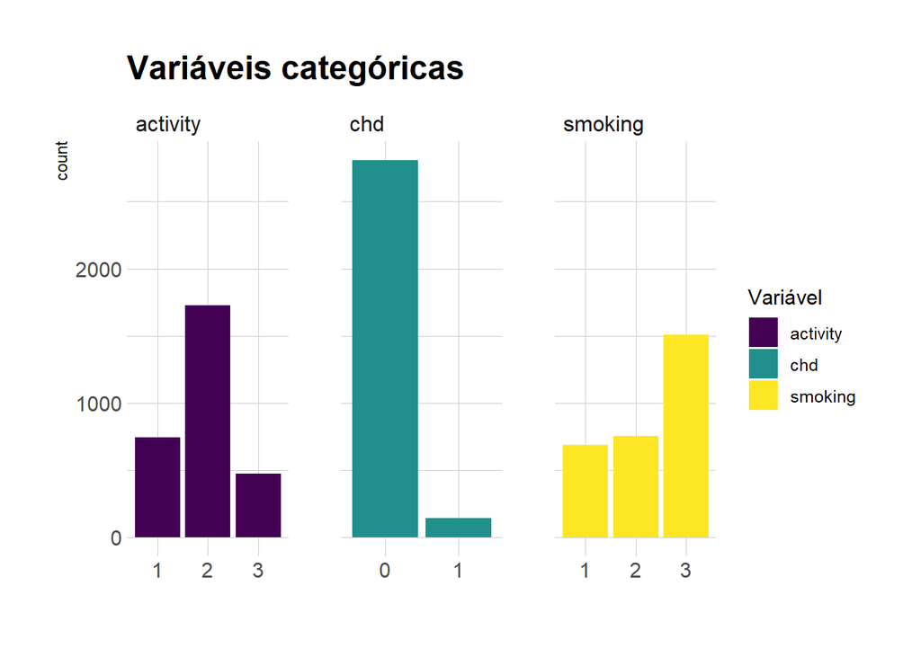

| VARIÁVEL | DESCRIÇÃO |
| --- | --- |
| smoking | Categorias do tabagismo: 1 = Nunca fumou 2 = Ex-tabagista 3 = Tabagista |
| activity | Autorrelato do nível de atividade física: 1 = Ativo 2 = Atividade média 3 = Inativo |
| chd | Incidência de doença cardiovascular (DCV) 0 = Não 1 = Sim |

# Correlação entre as variáveis

Podemos começar nossas análises explorando a associação entre as variáveis através da representação gráfica da matriz de correlações de Pearson

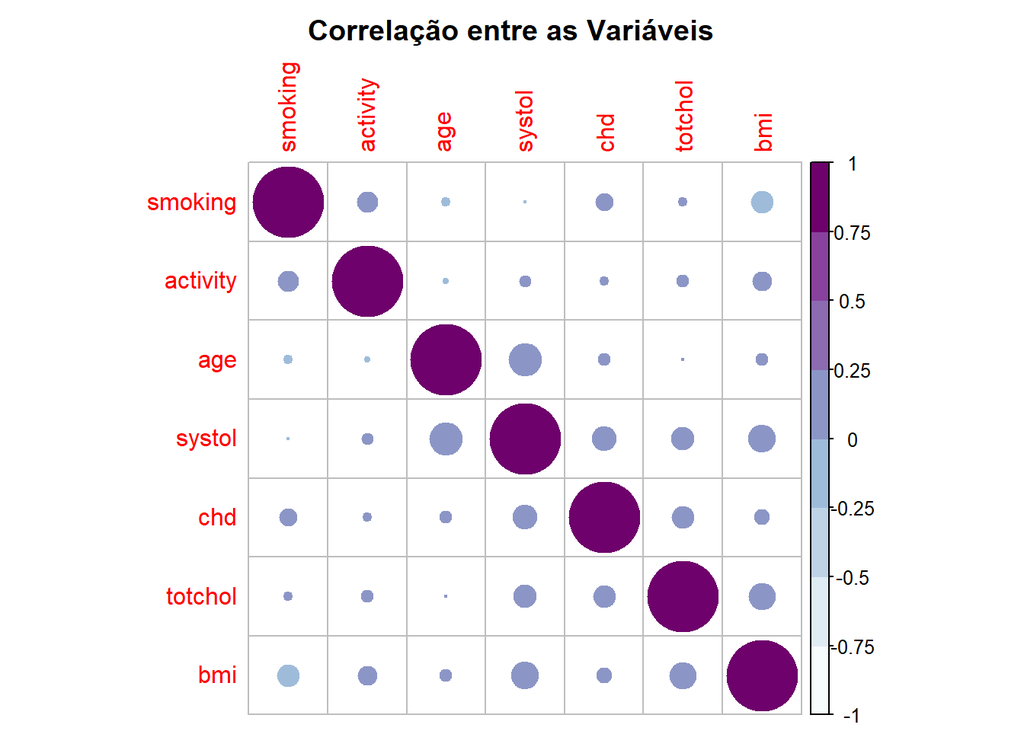

```r
M <- dados_tabagismo %>% select(-c("id")) %>% cor()

corrplot(M, title="Correlação entre as Variáveis", mar=c(0, 0, 2, 0), type = "full", order="hclust", col=brewer.pal(n=8, name="BuPu"))
```

Podemos notar no gráfico (acima) que as variáveis preditoras não estão significativamente correlacionadas, o que nos dá indícios de que multicolinearidade não será um problema na parametrização dos nossos modelos.

# Regressão Logística

### Modelo 1

```r
dados_tabagismo[, var_cat] <- aux1 # deixando as variáveis categóricas como fator

modelo1 <- glm(chd~totchol, family = binomial(logit), data = dados_tabagismo)
summary(modelo1)
```

```
##
## Call:
## glm(formula = chd ~ totchol, family = binomial(logit), data = dados_tabagismo)
##
## Deviance Residuals:
##     Min       1Q   Median       3Q      Max
## -0.8154  -0.3360  -0.2933  -0.2580   2.7975
##
## Coefficients:
##             Estimate Std. Error z value Pr(>|z|)
## (Intercept) -5.29894    0.47834 -11.078  < 2e-16 ***
## totchol      0.35101    0.06899   5.088 3.61e-07 ***
## ---
## Signif. codes:  0 '***' 0.001 '**' 0.01 '*' 0.05 '.' 0.1 ' ' 1
##
## (Dispersion parameter for binomial family taken to be 1)
##
##     Null deviance: 1138.7  on 2950  degrees of freedom
## Residual deviance: 1114.0  on 2949  degrees of freedom
## AIC: 1118
##
## Number of Fisher Scoring iterations: 6
```

### Modelo 2

```r
modelo2 <- glm(chd~totchol+age, family = binomial(logit), data = dados_tabagismo)
summary(modelo2)
```

```
##
## Call:
## glm(formula = chd ~ totchol + age, family = binomial(logit),
##     data = dados_tabagismo)
##
## Deviance Residuals:
##     Min       1Q   Median       3Q      Max
## -0.7684  -0.3374  -0.2919  -0.2538   2.7584
##
## Coefficients:
##             Estimate Std. Error z value Pr(>|z|)
## (Intercept) -6.53052    0.91447  -7.141 9.24e-13 ***
## totchol      0.35444    0.06940   5.107 3.27e-07 ***
## age          0.02444    0.01529   1.598     0.11
## ---
## Signif. codes:  0 '***' 0.001 '**' 0.01 '*' 0.05 '.' 0.1 ' ' 1
##
## (Dispersion parameter for binomial family taken to be 1)
##
##     Null deviance: 1138.7  on 2950  degrees of freedom
## Residual deviance: 1111.4  on 2948  degrees of freedom
## AIC: 1117.4
##
## Number of Fisher Scoring iterations: 6
```

```r
anova(modelo1, modelo2, test = "Chisq") # teste da razão de verossimilhança entre dois modelos encaixados utilizando a distribuição Qui - Quadrado
```

```
## Analysis of Deviance Table
##
## Model 1: chd ~ totchol
## Model 2: chd ~ totchol + age
##   Resid. Df Resid. Dev Df Deviance Pr(>Chi)
## 1      2949     1114.0
## 2      2948     1111.4  1   2.5635   0.1094
```